# Tidy (Art Historical) Data

September 23, 2015

## Making a tidy table

## What is tidy data?

1. One variable per column
2. One observation per row
3. Consistent data types
4. If you can't do 1 and 2, that means you need an extra table

## Why?

1. Make it easy to analyze at scale
2. Make it easy to share
3. Make it easy to recombine with other data

## Messy (but well-intentioned!) data

| acq_no | artist_1 | artist_2 | date | medium | tags |
| --- | --- | --- | --- | --- | --- |
| 1999.32 | Studio of Rembrandt | possibly Govaert Flinck | after 1636 | oil on canvas | religious, portrait |
| 1908.54 | Jan Vermeer | NA | c. 1650 | oil on panel | genre, woman |
| 1955.32 | Vermeer, Jan | NA | c. 1655 | oil on canvas | woman, window, painting |
| 1955.33 | Hals, Frans | NA | 16220 | oil on canvas, relined | merry company |

- On the plus side, there is a unique ID column!

## One variable per column

| acq_no | artist_1 | artist_2 | date | medium | tags |
| --- | --- | --- | --- | --- | --- |
| 1999.32 | Studio of Rembrandt | possibly Govaert Flinck | after 1636 | oil on canvas | religious, portrait |
| 1908.54 | Jan Vermeer | NA | c. 1650 | oil on panel | genre, woman |
| 1955.32 | Vermeer, Jan | NA | c. 1655 | oil on canvas | woman, window, painting |
| 1955.33 | Hals, Frans | NA | 16220 | oil on canvas, relined | merry company |

- `artist_1`: first and last names combined; conditionals
- `date`: conditionals
- `medium`: medium and support combined; conditionals

## One observation per row

| acq_no | artist_1 | artist_2 | date | medium | tags |
| --- | --- | --- | --- | --- | --- |
| 1999.32 | Studio of Rembrandt | possibly Govaert Flinck | after 1636 | oil on canvas | religious, portrait |
| 1908.54 | Jan Vermeer | NA | c. 1650 | oil on panel | genre, woman |
| 1955.32 | Vermeer, Jan | NA | c. 1655 | oil on canvas | woman, window, painting |
| 1955.33 | Hals, Frans | NA | 16220 | oil on canvas, relined | merry company |

- `tags` and `artists` need to be their own tables

## Consistent types and values

| acq_no | artist_1 | artist_2 | date | medium | tags |
| --- | --- | --- | --- | --- | --- |
| 1999.32 | Studio of Rembrandt | possibly Govaert Flinck | after 1636 | oil on canvas | religious, portrait |
| 1908.54 | Jan Vermeer | NA | c. 1650 | oil on panel | genre, woman |
| 1955.32 | Vermeer, Jan | NA | c. 1655 | oil on canvas | woman, window, painting |
| 1955.33 | Hals, Frans | NA | 16220 | oil on canvas, relined | merry company |

- `date` has typos
- `date` could potentially be numeric

## Tidied data

## Objects

Three conceptual tables: objects, artist links, and tags.

| acq_no | date | date_qual | medium | support | cons_note |
| --- | --- | --- | --- | --- | --- |
| 1999.32 | 1636 | after | oil | canvas | NA |
| 1908.54 | 1650 | circa | oil | panel | NA |
| 1955.32 | 1655 | circa | oil | canvas | NA |
| 1955.33 | 1620 | NA | oil | canvas | relined |

## Object-Artist

| acq_no | name | qualification |
| --- | --- | --- |
| 1999.32 | Rembrandt | studio of |
| 1999.32 | Govaert Flinck | possibly |
| 1908.54 | Jan Vermeer | NA |
| 1955.32 | Jan Vermeer | NA |
| 1955.33 | Frans Hals | NA |

## Object-Tags

| acq_no | tag |
| --- | --- |
| 1999.32 | religious |
| 1999.32 | portrait |
| 1908.54 | genre |
| 1908.54 | woman |
| 1955.32 | woman |
| 1955.32 | window |
| 1955.32 | painting |
| 1955.33 | merry_company |

By separating out tables, we can be more flexible with the types of questions we can ask.

```r
# What paintings have the tag "woman"?
clean_data_obj %>%
  inner_join(clean_data_tags, by = "acq_no") %>%
  filter(tag == "woman") %>% kable()
```

| acq_no | date | date_qual | medium | support | cons_note | tag |
| --- | --- | --- | --- | --- | --- | --- |
| 1908.54 | 1650 | circa | oil | panel | NA | woman |
| 1955.32 | 1655 | circa | oil | canvas | NA | woman |

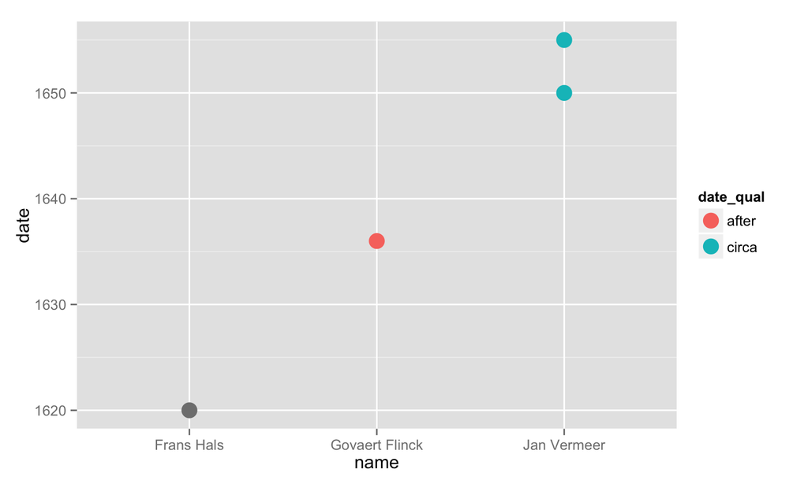

```r
# When was each painter working?
clean_data_obj %>%
  inner_join(clean_data_artist, by = "acq_no") %>%
  filter(is.na(qualification) | qualification != "studio of") %>%
  ggplot(aes(x = name, y = date, color = date_qual)) +
  geom_point(size = 5)
```

## Tips for Historical Datasets

- Use a structured vocabulary when there are a limited number of possible values for a column. This allows easier counting and better consistency across your data.
- Be consistent with date formats.
  - If you have day-level info for some entries, and only year level for others, think about putting in `1701-01-01`, or have separate columns for year, month, day.
  - Do some records have a start and end date? Have a `start_date` and `end_date`
- A loose "notes" column is fine, but if you find yourself frequently making a similar type of note (e.g. `citation`) then you probably need to make a new column just for that information.

## Tips for Historical Datasets II

- "Uncertain" values
  - `[?]` is not informative. What about: `illegible`, `unsubstantiated`, `approximate`?
  - Make an uncertainty vocabulary if you have to, so the terms are controlled, countable, and documented
  - Use separate columns liberally, e.g. `date`, `date_uncertainty`
- You can't document everything! If some tricky field is just not relevant enough to your research, then don't kill yourself trying to capture it with perfect specificity.
- **It is easy to recombine columns later. It is very hard to split them out.**

## Documenting tidy data

## Do it for future-you & for others

- You **will** forget what you did in a few months. Or even a few days. Docs will remind you.
- Docs make writing reports/articles easier
- Docs make your data reusable:
  - others won't have to guess at what a certain column means
  - or what decisions you made when recording it
  - or how to cite it
  - or if/how they may reuse it

## Show your work

- Describe what you made:
  - Keep a plain text doc in the same directory as your tables
  - Have a heading for each table
  - List every column name and describe what it means
    - Incl. list of possible values, relation to other tables as appropriate
- Document the process
  - Did you adapt this from another dataset? (incl. original data, or link)
  - Describe the transformations you made, including what software you used

## Sharing tidy data

## Flat Files, Not Live Servers

Omeka and the like are great for interactively communicating stories and selections from your research. They are not a storage and dissemination solution *in the long run*. Costly, fragile, limiting.

"Flat files" are decoupled from running software, and can be opened by a regular text editor. Someone without your original software has a better chance of recovering the information.

## Plaintext

- Use plain text file types for tables and docs (`.txt`, `.csv`, not `.xslx`)
  - Free
  - Somewhat more future-proof
  - Track-able
- Creating in Excel/Google Sheets is fine, you can export it
  - When saving in Excel, use `UTF-8` so that accents & special characters are preserved
  - Don't rely on meaningful formatting (colored cells, bold, italics, borders), because that won't be preserved
  - Save multiple versions

## Archive it

- Bundle data and documentation in the same directory and zip them.
- Distribute
  - Institutional repository (upload it with your dissertation)
  - Journal websites
  - [Zenodo](https://zenodo.org/)
  - [Git](https://git-scm.com/) (works great with all-text files - more and more libraries and journals will be moving towards this method for tracking file versions)

## Resources

- [See a tidy data example](https://github.com/mdlincoln/tidy-arth-data/tree/gh-pages/example_data)
- Database management
  - [Google Fusion Tables](https://www.google.com/fusiontables/)
  - [UCLA DH101: Data and Databases](http://dh101.humanities.ucla.edu/?page_id=93)
  - [Designing Databases for Historical Research](http://port.sas.ac.uk/mod/book/view.php?id=75) (great intro to relational DBs)
- Data cleaning with [OpenRefine](http://programminghistorian.org/lessons/cleaning-data-with-openrefine)